# SMI610, day 3

15 June 2022

## What’s happening today (and tomorrow)?

We’re talking about social network analysis. The rhythm of the days will be pretty similar to Monday, with a mix of lecture material, working through the handout collectively, and working through the tasks on the handout individually.

## Social network analysis

## What is a network?

A network is a way to represent the connections between things. These can be:

- social (who tweets at whom)
- economic (which companies employ which people)
- engineering (which parts are used in which products)
- geospatial (which trains travel to which stations)
- health-related (how do neurons fire in cognitive function)
- machine learning (you’ve heard the term “neural network”)

etc

## Time for some maths

## Notation

A graph \(G\) is mathematically written as

\[G = (V,E)\]

where

- \(V\) is a set of vertices (or nodes)
- \(E\) is a set of edges (or ties, connections, etc)

The () notation is crucial: it means the order is significant.

For people familiar with python: these are like `tuples`.

## Unordered notation

If the order doesn’t matter: we use \({}\) instead of \(()\).

If we’re looking at vertices, the order doesn’t matter. For example:

\[ V = \{1, 2, 4, 7\} \]

## Edges

Edges connect nodes and are also sets. There are two basic types:

- Directed - Order matters (Sally follows Bob, Bob follows Beth, Beth follows Sally)
- Undirected - Order doesn’t matter (Sally and Bob are Facebook friends, Bob and Beth are Facebook friends)

## Undirected edges

Undirected edges are (relatively) more straightforward. When people are Facebook friends with one another, we can represent these relationships as subsets of the set of edges:

\[ E = \{\{Sally, Bob\}, \{Bob, Beth\}\} \]

This is equivalent to:

\[ E = \{\{Bob, Sally\}, \{Beth, Bob\}\} \]

because order doesn’t matter in undirected graphs, hence each pair is a set.

(in this case, the set of edges is every single Facebook friendship)

## Directed edges

In directed edges, the order matters. I follow Jorts the Cat on Twitter, but Jorts the Cat doesn’t follow me. My partner and I both follow Jorts the Cat. So:

\[ E = \{(markrt, JortsTheCat), (markrt, RedactedPartner),\] \[(RedactedPartner, JortsTheCat), (RedactedPartner, markrt)\} \] but not

\[ E = \{(JortsTheCat, markrt), (markrt, RedactedPartner),\] \[(JortsTheCat, RedactedPartner), (RedactedPartner, markrt)\} \]

## Revisiting the original note

\[ G = (V, E) \]

is not equivalent to

\[ G = (E, V) \]

because it does matter that \(V\) preceeds \(E\), both are sets, and \(E\) could be a set of sets, or a set of ordered pairs (like a python `set` of `tuple` objects).

## Edges in undirected networks

- Connected
  - \(a\) is linked to \(b\)
  - \(\{a, b\} \in E\)
- Unconnected
  - \(a\) is not linked to \(b\)
  - \(\{a, b\} \notin E\)

## Edges in directed networks

- Unidirectional
  - connection from \(a\) to \(b\)
  - \((a, b) \in E \land (b, a) \notin E\)
- Bidirectional
  - connections from \(a\) to \(b\) and \(b\) to \(a\)
  - \(\{(a, b), (b, a)\} \in E\)
- Unconnected
  - a is not linked to b
  - \((a, b) \notin E \land (b, a) \notin E\)

## What does it look like?

## Networks in practice

Start with the simplest possible network: me and Jorts. Four possible configurations of who follows whom:

- Jorts and I follow each other
- I follow Jorts, but Jorts doesn’t follow me
- Jorts follows me, but I don’t follow Jorts
- Jorts doesn’t follow me, I don’t follow Jorts

## Different network formats

Broadly (this is a bit reductive) there are two ways to encode network information: adjacency matrices and edgelists. Let’s illustrate these using me and Jorts.

## Jorts

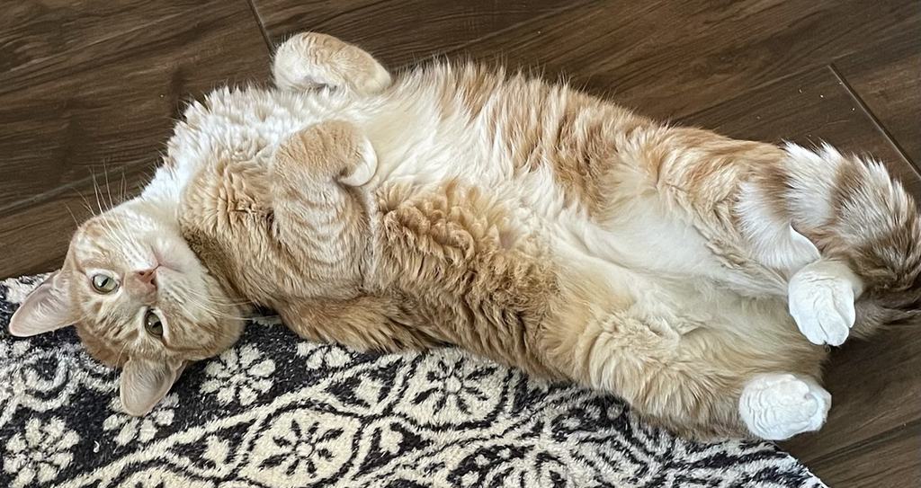

## Jorts and I follow each other

Adjacency matrix: \[ \begin{array}{cc} & Jorts & Mark\\ Jorts & 0 & 1 \\ Mark & 1 & 0 \end{array} \]

Edgelist \[ \begin{array}{cc} Source & Target\\ Jorts & Mark \\ Mark & Jorts \end{array} \]

## I follow Jorts, but Jorts doesn’t follow me

Adjacency matrix:

\[ \begin{array}{cc} & Jorts & Mark\\ Jorts & 0 & 0 \\ Mark & 1 & 0 \end{array} \]

Edgelist:

\[ \begin{array}{cc} Source & Target\\ Mark & Jorts \end{array} \]

## Jorts follows me, but I don’t follow Jorts

Adjacency matrix: \[ \begin{array}{cc} & Jorts & Mark\\ Jorts & 0 & 1 \\ Mark & 0 & 0 \end{array} \]

Edgelist \[ \begin{array}{cc} Source & Target\\ Jorts & Mark \end{array} \]

## Jorts doesn’t follow me, I don’t follow Jorts

Adjacency matrix: \[ \begin{array}{cc} & Jorts & Mark\\ Jorts & 0 & 0 \\ Mark & 0 & 0 \end{array} \]

Edgelist:

## Undirected networks have symmetrical adjacency matrices

\[ \begin{array}{cc} & Alice & Bob & Chris\\ Alice & 0 & 1 & 1 \\ Bob & 1 & 0 & 0 \\ Chris & 1 & 0 & 0\\ \end{array} \]

## This is the end of the bit where I explain how networks work

## Network-level definitions

## Size

The **size** of the network is usually given as the overall number of edges. Assuming no reflexive ties, the maximum size of a directed network is

\[ n(n-1) \]

and the maximum size of an undirected network is

\[ \frac{n(n - 1)}{2} \]

## Density

Density is a measure of how many edges there are, also knows as the *cardinality* of a network, divided by how many *possible* connections there could be.

Directed density:

\[\frac{m}{n(n-1)}\]

Undirected density:

\[\frac{m}{n(n-1)/2}\]

where \(m\) is the number of edges cardinality and \(n\) is the number of nodes.

## Components

Components are also sometimes referred to as subgraphs: they’re parts of networks where there are paths between all nodes. Number of components is a measure we often report.

### Diameter

Diameter is the longest shortest path. To unpack: find the shortest paths between every pair of nodes within the same component and then find the maximum of those shortest paths. Once again undirected vs directed makes a difference.

## Reciprocity

Reciprocity is the fraction of cases where ties are reciprocated (and therefore only really applies to directed networks)

## Transitivity

If Alice and Bob are friends, and Alice and Chris are friends, what’s the probability that Bob and Chris are friends?

Transitivity is the proportion of triads of nodes with at least two edges that have the third edge as well.

## Node-level definitions

## Degree

Node-level degree is a measure of the number of edges each node has. In undirected graphs it’s straightforward, in directed graphs we distinguish this into:

- out-degree (edges where the node is the source)
- in-degree (edges where the node is the target)

## Betweenness

Of all the shortest paths in the network, how many pass through each given node? In this case we’re looking at node x and all shortest paths between all nodes y and z.

\[ C_b(x) = \sum_{y \neq x \neq z \in V}{\frac{\sigma_{yz}(x)}{\sigma_{yz}}} \]

## Closeness

How far is a given node from other nodes? Closeness centrality measures how close node is to other nodes by taking the inverse of the sum of path lengths to all other nodes.

\[ C_c(x) = \frac{1}{\sum_y{d(x, y)}} \]

## Lots of other measures

Eigenvector centrality, PageRank…

Decision about which measure to use should be theoretically informed (if you want to use the word “gatekeeper”, betweenness probably better than closeness…)

Often (not always!) pretty highly correlated with one other

## Community detection

## Cliques

A clique’s a group of nodes in which each one’s connected to each other

Not necessarily that helpful for answering research questions

## Community detection algorithms

| Name | Function | Directed | Weighted | Components |
| --- | --- | --- | --- | --- |
| Edge-betweenness | cluster_edge_betweenness | 👍 | 👍 | 👍 |
| Leading eigenvector | cluster_leading_eigen | 👎 | 👎 | 👍 |
| Fast-greedy | cluster_fast_greedy | 👎 | 👍 | 👍 |
| Louvain | cluster_louvain | 👎 | 👍 | 👍 |
| Walktrap | cluster_walktrap | 👎 | 👍 | 👎 |
| Label propagation | cluster_label_prop | 👎 | 👍 | 👎 |
| InfoMAP | cluster_infomap | 👍 | 👍 | 👍 |
| Spinglass | cluster_spinglass | 👎 | 👍 | 👎 |
| Optimal | cluster_optimal | 👎 | 👍 | 👍 |

## Things we haven’t talked about

## Things we haven’t talked about

Loads:

- Egonets
- Qualitative network analysis
- Networks with categorical edges
- Networks with more than one type of edge
- Change over time
- Negative ties
- Multilevel networks
- Spatial networks
- etc

## Things we haven’t talked about

Modelling

- Erdős–Rényi models
- Small world models
- Scale-free models
- Exponential random graph models (ERGMs) Simulation more generally